# Queller-Phil-ADA-homework-2

Phil Queller

3/7/2020

## Homework 2

```r
library(ggplot2)
library(tidyverse)
library(dplyr)
library(mosaic)
library(curl)
```

# Challenge 1

```r
m <- read_csv("~/movies.csv")
head(m)
```

```
## # A tibble: 6 x 10
##   tconst titleType primaryTitle startYear runtimeMinutes genres averageRating
##   <chr>  <chr>     <chr>            <dbl>          <dbl> <chr>          <dbl>
## 1 tt000… movie     Dante's Inf…      1911             68 Adven…           7
## 2 tt000… movie     Fantômas: I…      1913             54 Crime…           7
## 3 tt000… movie     Fantomas: T…      1913             61 Crime…           7
## 4 tt000… movie     Fantômas: T…      1913             90 Crime…           7
## 5 tt000… movie     The Student…      1913             85 Drama…           6.5
## 6 tt000… movie     The Avengin…      1914             78 Crime…           6.5
## # … with 3 more variables: numVotes <dbl>, nconst <chr>, director <chr>
```

Use a one-line statement to filter the dataset to include just movies from 1920 to 1979 and movies that are less than 4 hours long (runtimeMinutes < 240), and add a new column that codes the startYear into a new variable, decade (“20s”, “30s”, …“70s”). If you do this correctly, there should be 5741 movies remaining in the dataset. Use {ggplot2} to plot histograms of the distribution of runtimeMinutes for each decade.

HINT: Try using facet_wrap() to do this!

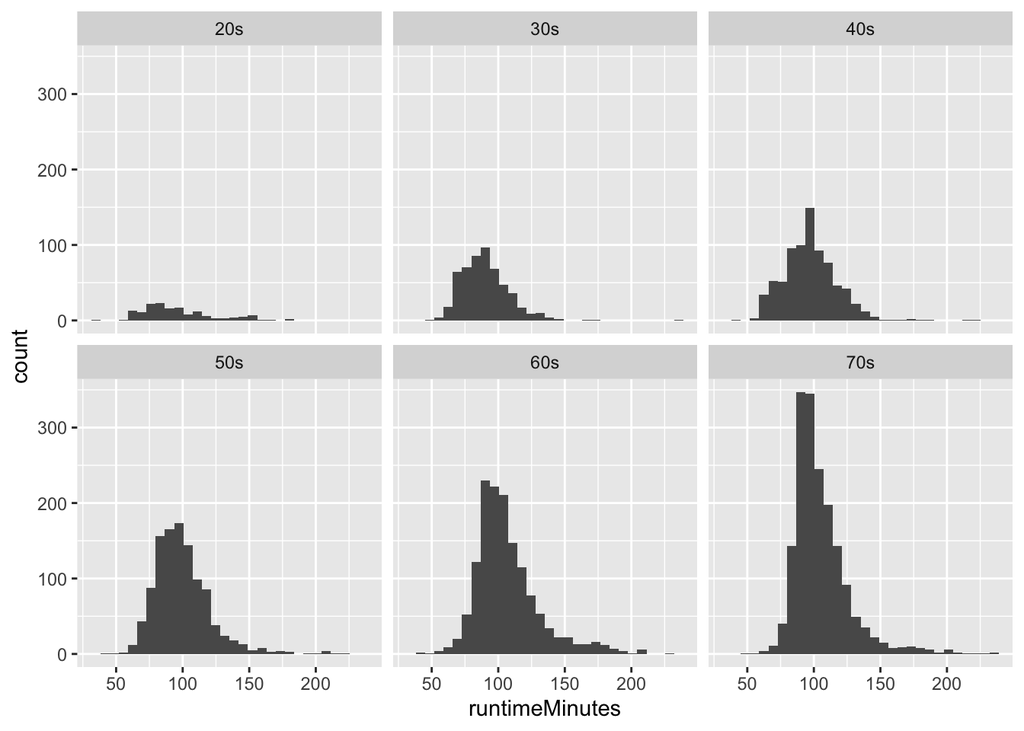

```r
m2 <- m %>% filter(runtimeMinutes < 240 & startYear %in% 1920:1979) %>%
  mutate(decade=case_when(startYear %in% 1920:1929 ~ "20s", startYear %in% 1930:1939 ~ "30s", startYear %in% 1940:1949 ~ "40s", startYear %in% 1950:1959 ~ "50s", startYear %in% 1960:1969 ~ "60s", startYear %in% 1970:1979 ~ "70s"))

m2 %>% ggplot(aes(x=runtimeMinutes)) +
  geom_histogram() +
  facet_wrap(~ decade)
```

```r
head(m2)
```

```
## # A tibble: 6 x 11
##   tconst titleType primaryTitle startYear runtimeMinutes genres averageRating
##   <chr>  <chr>     <chr>            <dbl>          <dbl> <chr>          <dbl>
## 1 tt001… movie     The Cabinet…      1920             76 Fanta…           8.1
## 2 tt001… movie     Leaves From…      1920            167 Drama            6.7
## 3 tt001… movie     Dr. Jekyll …      1920             82 Drama…           7
## 4 tt001… movie     The Golem         1920             76 Fanta…           7.2
## 5 tt001… movie     The Last of…      1920             73 Actio…           6.7
## 6 tt001… movie     The Mark of…      1920            107 Adven…           7.1
## # … with 4 more variables: numVotes <dbl>, nconst <chr>, director <chr>,
## #   decade <chr>
```

Use a one-line statement to calculate the population mean and population standard deviation in runtimeMinutes for each decade and save the results in a new dataframe, results.

HINT: Use {dplyr} functions and the pipe operator!

```r
results <- m2 %>% group_by(decade) %>% summarise(pop_mean = mean(runtimeMinutes), pop_standard_deviation = sd(runtimeMinutes))
head(results)
```

```
## # A tibble: 6 x 3
##   decade pop_mean pop_standard_deviation
##   <chr>     <dbl>                  <dbl>
## 1 20s        96.0                   27.5
## 2 30s        90.2                   18.7
## 3 40s        97.3                   20.6
## 4 50s        99.6                   21.6
## 5 60s       107.                    24.3
## 6 70s       105.                    21.4
```

Draw a single sample of 100 movies from each decade, calculate this single sample mean and sample standard deviation in runtimeMinutes, and estimate the SE around the population mean runtimeMinutes for each decade based on the standard deviation and sample size from these samples.

```r
set.seed(100)
n <- 100
s <- sample_n(m2, size = n, replace = FALSE)
sample_summary <- s %>% group_by(decade) %>% summarise(sample_mean = mean(runtimeMinutes), sample_standard_deviation = sd(runtimeMinutes))
head(sample_summary)
```

```
## # A tibble: 5 x 3
##   decade sample_mean sample_standard_deviation
##   <chr>        <dbl>                     <dbl>
## 1 30s           98.2                      25.8
## 2 40s           96.9                      16.7
## 3 50s          102.                       19.7
## 4 60s          105                        21.9
## 5 70s          113.                       25.6
```

```r
se_mean_runtimeminutes <- sample_summary %>% mutate(sample_standard_error = (sample_standard_deviation/sqrt(n)))
head(se_mean_runtimeminutes)
```

```
## # A tibble: 5 x 4
##   decade sample_mean sample_standard_deviation sample_standard_error
##   <chr>        <dbl>                     <dbl>                 <dbl>
## 1 30s           98.2                      25.8                  2.58
## 2 40s           96.9                      16.7                  1.67
## 3 50s          102.                       19.7                  1.97
## 4 60s          105                        21.9                  2.19
## 5 70s          113.                       25.6                  2.56
```

Compare these estimates to the actual population mean runtimeMinutes and to the calculated SE in the population mean for samples of size 100 based on the population standard deviation for each decade.

```r
pop_vs_sample <- inner_join(results, se_mean_runtimeminutes, by = "decade")
head(pop_vs_sample)
```

```
## # A tibble: 5 x 6
##   decade pop_mean pop_standard_de… sample_mean sample_standard… sample_standard…
##   <chr>     <dbl>            <dbl>       <dbl>            <dbl>            <dbl>
## 1 30s        90.2             18.7        98.2             25.8             2.58
## 2 40s        97.3             20.6        96.9             16.7             1.67
## 3 50s        99.6             21.6       102.              19.7             1.97
## 4 60s       107.              24.3       105               21.9             2.19
## 5 70s       105.              21.4       113.              25.6             2.56
```

std dev of mean / sqrt of sample = stdev of sample distribution

Generate a sampling distribution of mean runtimeMinutes for each decade by [a] drawing 10,000 samples of 100 movies from each decade and, for each sample, [b] calculating the mean runtimeMinutes and the standard deviation in runtimeMinutes. Recall that the standard deviation of the sampling distribution is another estimate of the standard error in the population mean for a particular sample size.

```r
n <- 100
set.seed(100)
reps <- 10000
sample_distribution_mean <-  do(reps) * mean(~runtimeMinutes, data = sample_n(m2, size = n, replace = FALSE))

sample_distribution_sd <- do(reps) * sd(~runtimeMinutes, data = sample_n(m2, size = n, replace = FALSE))

head(sample_distribution_sd)
```

```
##         sd
## 1 24.06707
## 2 21.45579
## 3 23.24858
## 4 22.68983
## 5 21.67319
## 6 20.98499
```

# Challenge 2

Every Saturday, at the same time, a primatologist goes and sits in the forest in the morning and listens for titi monkey calls, counting the number of calls they hear in a 3 hour window from 5am to 8am. Based on previous knowledge, she believes that the mean number calls she will hear in that time is 18. Let X represent the appropriate Poisson random variable of the number of calls heard in each monitoring session.

What is the probability that she will hear 13 or fewer calls during any given session?

```r
ppois(13, lambda = 18)
```

```
## [1] 0.1425978
```

What is the probability that she will hear no calls in a session?

```r
dpois(0, lambda = 18)
```

```
## [1] 1.522998e-08
```

What is the probability that she will hear exactly 7 calls in a session?

```r
dpois(7, lambda = 18)
```

```
## [1] 0.00185002
```

What is the probability that she will hear more than 20 calls in a session?

```r
ppois(20, lambda = 18, lower.tail = FALSE)
```

```
## [1] 0.2692798
```

Plot the relevant Poisson mass function over the values in range 0 ≤ x ≤ 40.

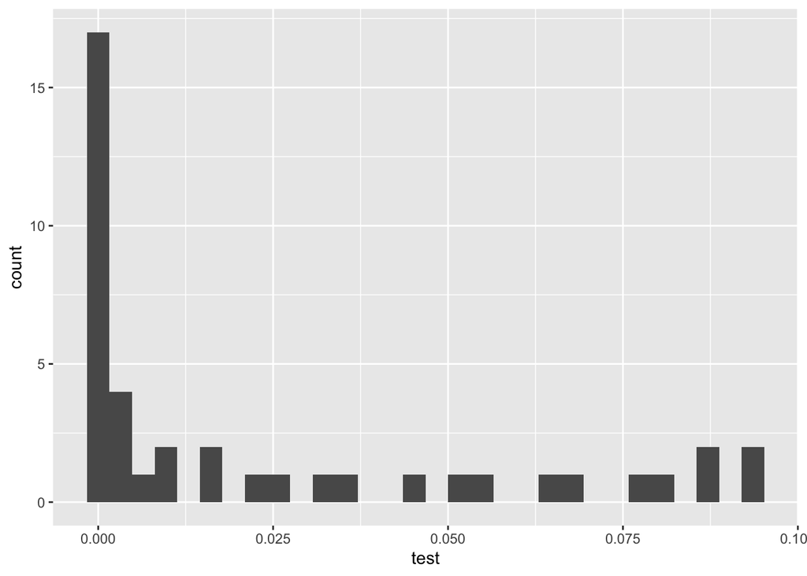

```r
test <- (dpois(0:40, lambda = 18))

ggplot(data = as.data.frame(test), aes(x=test)) + geom_histogram()
```

# Challenge 3

Load in the dataset “zombies.csv” from the ADA-datasets repository on GitHub as a “tibble”, d. The URL for the data file is “https://raw.githubusercontent.com/difiore/ADA-datasets/master/zombies.csv”. This data includes the first and last name and gender of the entire population of 1000 people who have survived the zombie apocalypse and are now ekeing out an existence somewhere on the East Coast, along with several other variables (height, weight, age, number of years of education, number of zombies they have killed, and college major). See here for info on important post-zombie apocalypse majors!

```r
f <- "https://raw.githubusercontent.com/difiore/ADA-datasets/master/zombies.csv"
d <- read_csv(f, col_names = TRUE)
head(d)
```

```
## # A tibble: 6 x 10
##      id first_name last_name gender height weight zombies_killed
##   <dbl> <chr>      <chr>     <chr>   <dbl>  <dbl>          <dbl>
## 1     1 Sarah      Little    Female   62.9   132.              2
## 2     2 Mark       Duncan    Male     67.8   146.              5
## 3     3 Brandon    Perez     Male     72.1   153.              1
## 4     4 Roger      Coleman   Male     66.8   130.              5
## 5     5 Tammy      Powell    Female   64.7   132.              4
## 6     6 Anthony    Green     Male     71.2   153.              1
## # … with 3 more variables: years_of_education <dbl>, major <chr>, age <dbl>
```

Calculate the population mean and standard deviation for each quantitative random variable (height, weight, age, number of zombies killed, and years of education).

```r
pop_means <- d %>% summarise(pop_mean_height = mean(height), pop_mean_weight = mean(weight), pop_mean_zkills = mean(zombies_killed), pop_mean_age = mean(age), pop_mean_yearsEDU = mean(years_of_education))
head(pop_means)
```

```
## # A tibble: 1 x 5
##   pop_mean_height pop_mean_weight pop_mean_zkills pop_mean_age pop_mean_yearsEDU
##             <dbl>           <dbl>           <dbl>        <dbl>             <dbl>
## 1            67.6            144.            2.99         20.0              3.00
```

```r
pop_stdvs <- d %>% summarise(pop_stdv_height = sqrt(sum((height - mean(height))^2 / length(height))), pop_stdv_weight = sqrt(sum((weight - mean(weight))^2 / length(weight))), pop_stdv_zkills = sqrt(sum((zombies_killed - mean(zombies_killed))^2 / length(zombies_killed))), pop_stdv_age = sqrt(sum((age - mean(age))^2 / length(age))), pop_stdv_yearsEDU = sqrt(sum((years_of_education - mean(years_of_education))^2 / length(years_of_education))))
pop_stdvs
```

```
## # A tibble: 1 x 5
##   pop_stdv_height pop_stdv_weight pop_stdv_zkills pop_stdv_age pop_stdv_yearsEDU
##             <dbl>           <dbl>           <dbl>        <dbl>             <dbl>
## 1            4.31            18.4            1.75         2.96              1.68
```

Use {ggplot2} and make scatterplots of height and weight in relation to age. Do these variables seem to be related? In what way?

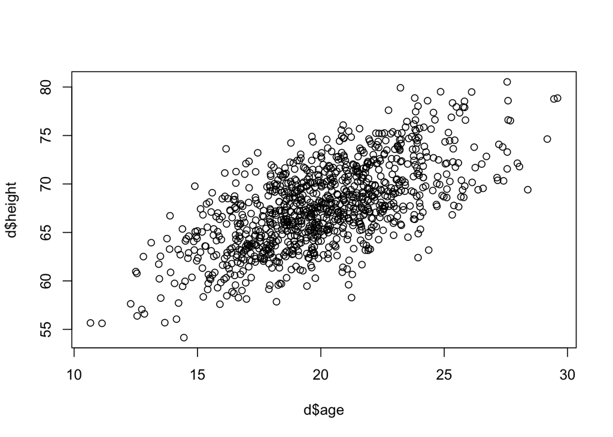

```r
height <- plot(x = d$age, y = d$height)
```

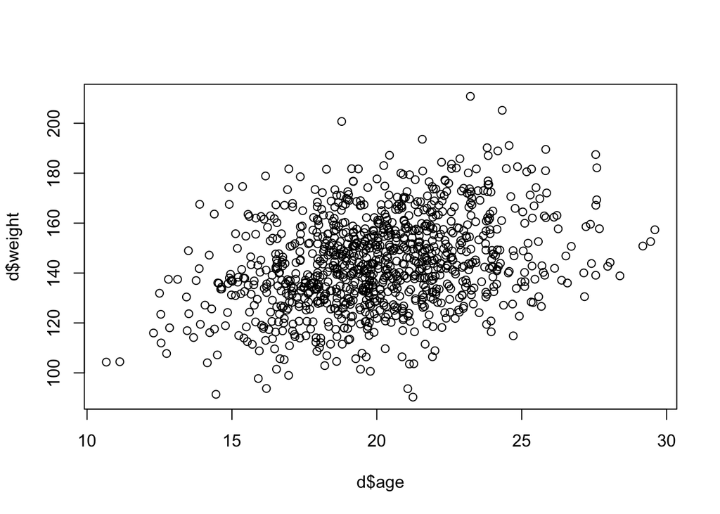

```r
weight <- plot(x = d$age, y = d$weight)
```

They seem to be positvely correlated.

Using histograms and Q-Q plots, check whether the quantitative variables seem to be drawn from a normal distribution. Which seem to be and which do not?

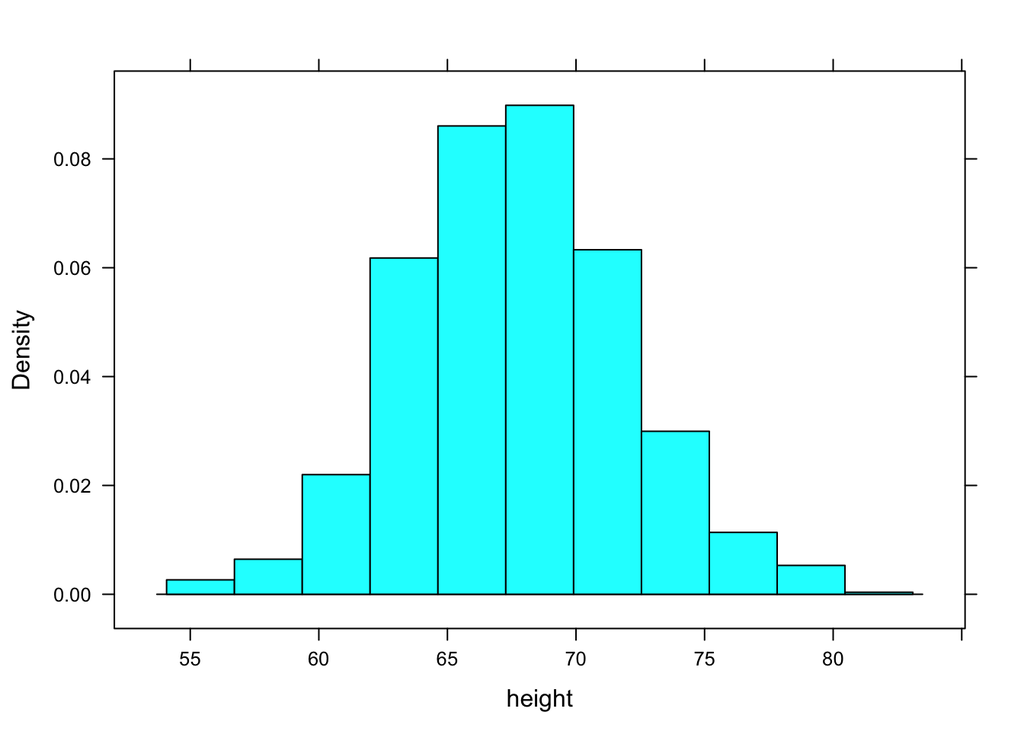

```r
histogram(~height, data = d)
```

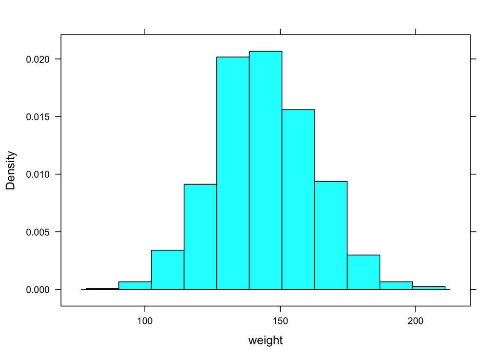

```r
histogram(~weight, data = d)
```

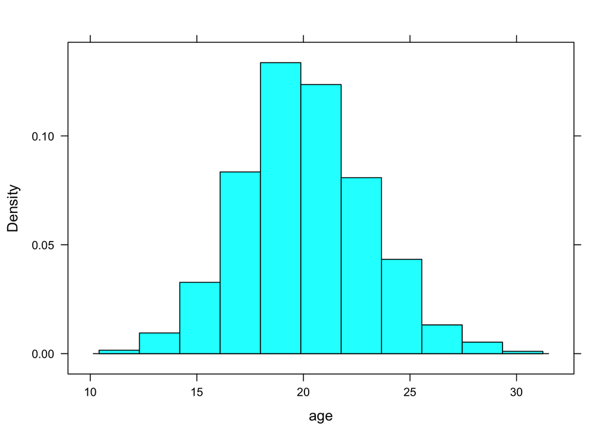

```r
histogram(~age, data = d)
```

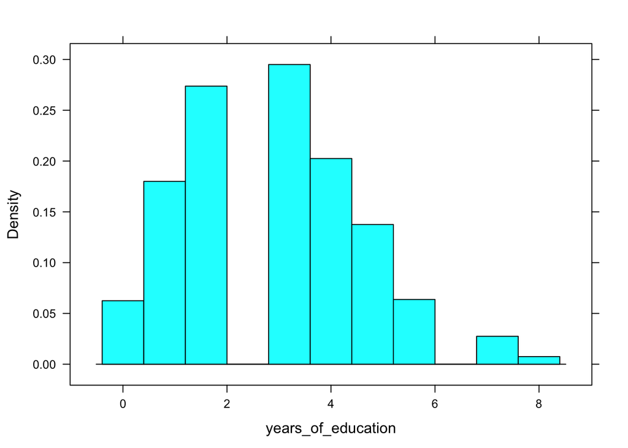

```r
histogram(~years_of_education, data = d)
```

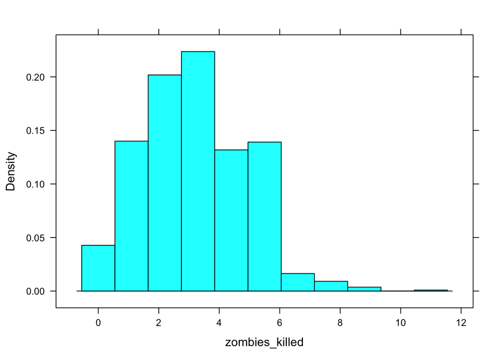

```r
histogram(~zombies_killed, data = d)
```

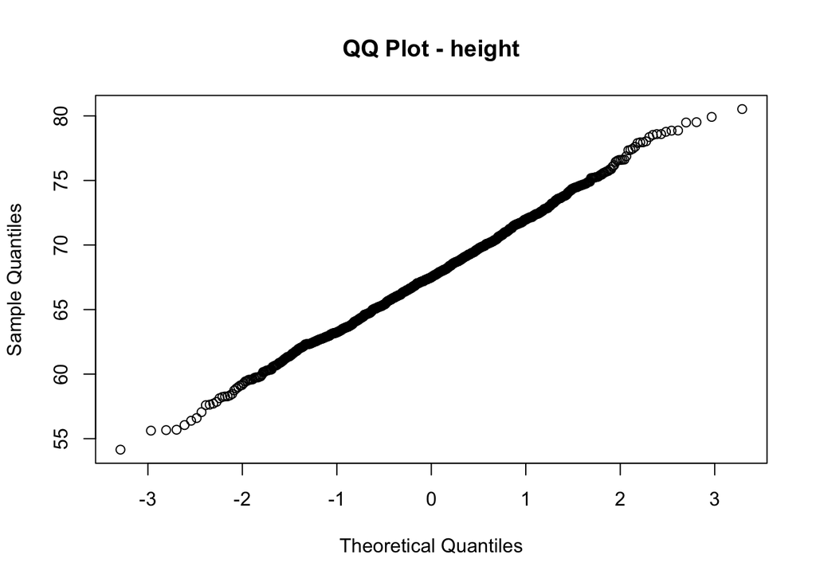

```r
d$height %>% qqnorm(main = "QQ Plot - height")
```

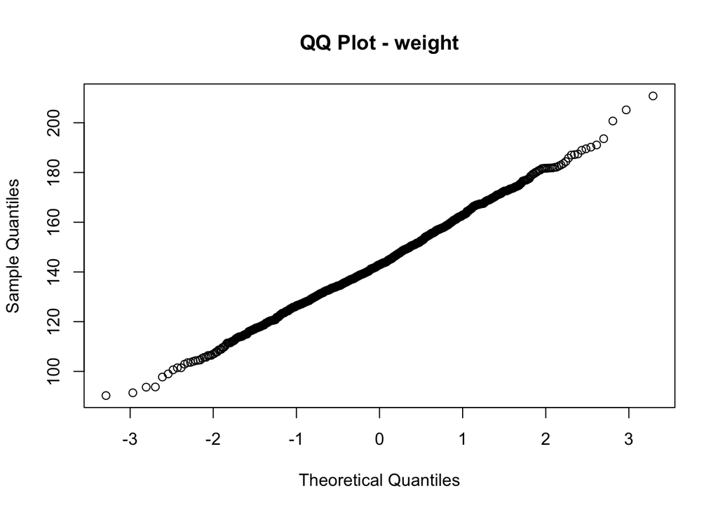

```r
d$weight %>% qqnorm(main = "QQ Plot - weight")
```

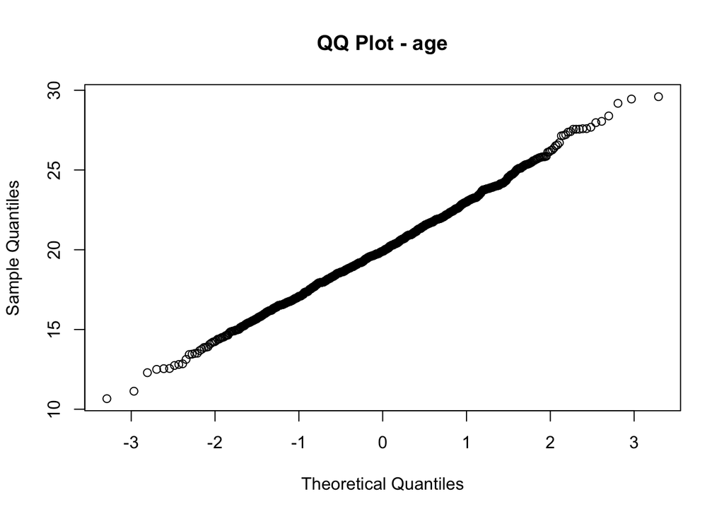

```r
d$age %>% qqnorm(main = "QQ Plot - age")
```

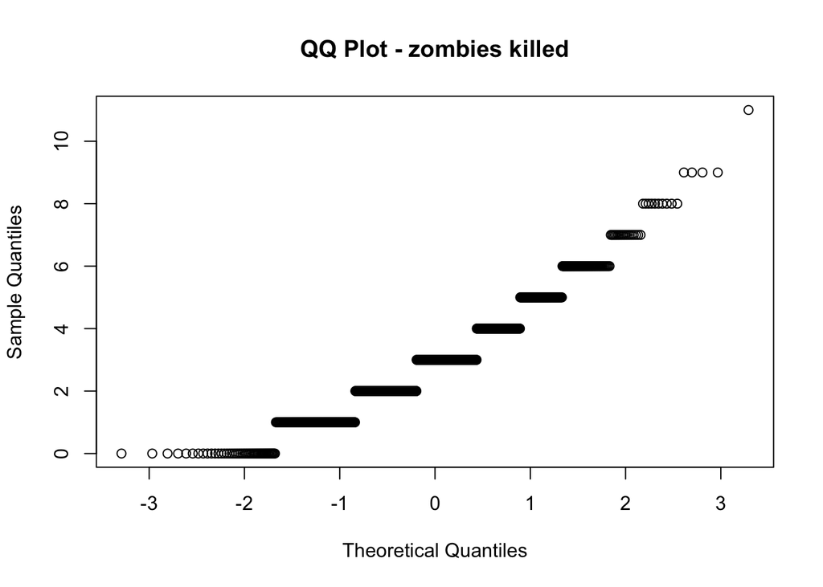

```r
d$zombies_killed %>% qqnorm(main = "QQ Plot - zombies killed")
```

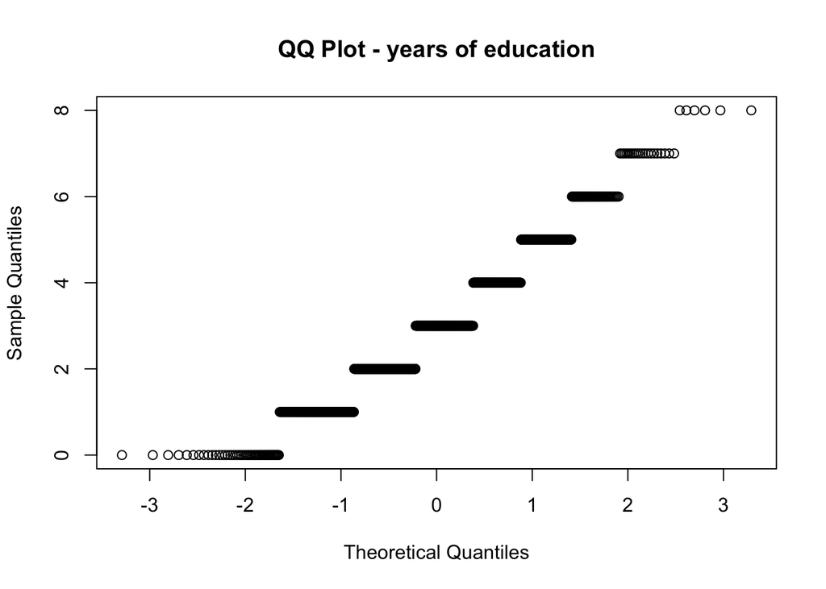

```r
d$years_of_education %>% qqnorm(main = "QQ Plot - years of education")
```

Years of education looks slightly bimodal and zombies killed isn’t as normal as the remaining variables by the histograms. The QQ plots better shows that zombies killed and years of education are not normally distributed variables.

Now use the sample_n() function from {dplyr} to sample ONE subset of 30 zombie apocalypse survivors (without replacement) from this population and calculate the mean and sample standard deviation for each variable. Also estimate the standard error for each variable and construct the 95% confidence interval for each mean. You can use either the standard normal or a Student’s t distribution to derive the critical values needed to calculate the lower and upper limits of the CI.

```r
thirty_survivors <- d %>% select(age, weight, height, zombies_killed, years_of_education)
z <- 30
sub_30 <- sample_n(thirty_survivors, size = z, replace = FALSE)
zage <- sub_30$age
zweight <- sub_30$weight
zheight <- sub_30$height
zyearsEDU <- sub_30$years_of_education
zzkills <- sub_30$zombies_killed

mean(zage)
```

```
## [1] 20.65582
```

```r
mean(zweight)
```

```
## [1] 145.1721
```

```r
mean(zheight)
```

```
## [1] 68.12104
```

```r
mean(zyearsEDU)
```

```
## [1] 2.966667
```

```r
mean(zzkills)
```

```
## [1] 2.466667
```

```r
sd_zage <- sd(zage)
sd_zweight <- sd(zweight)
sd_zheight <- sd(zheight)
sd_zyearsEDU <- sd(zyearsEDU)
sd_zzkills <- sd(zzkills)

se_age <- sd_zage/sqrt(30)
se_height <- sd_zheight/sqrt(30)
se_weight <- sd_zweight/sqrt(30)
se_yearsEDU <- sd_zyearsEDU/sqrt(30)
se_zkills <- sd_zzkills/sqrt(30)
```